# Exercises for Lecture Block 1

- Play around with jupyter notebooks
- Learn about useful Python libraries for machine learning
- Implement the forward pass for a minimal neural network (logistic regression)
- Implement the forward pass for a bigger neural network

## Useful Python Libraries

- [Scikit-learn](http://scikit-learn.org) (package name `sklearn`) is a machine learning library built on NumPy, SciPy and matplotlib.
- [NumPy](http://www.numpy.org/) is the fundamental package for scientific computing with Python.
- [SciPy](https://www.scipy.org/) is a Python-based ecosystem of open-source software for mathematics, science, and engineering.
- [Matplotlib](https://matplotlib.org/) is a graph plotting library.

```python
%matplotlib inline
import matplotlib.pyplot as plt
import numpy as np
from sklearn.datasets import make_blobs, make_moons
from sklearn.linear_model import LogisticRegression
from sklearn.model_selection import train_test_split
from sklearn.metrics import accuracy_score, precision_score, recall_score, f1_score
from sklearn.externals import joblib

SEED = 12345
```

## Generate Data

After making the relevant imports (above), we can use Scikit-learn's [make_blobs](http://scikit-learn.org/stable/modules/generated/sklearn.datasets.make_blobs.html) to generate an example dataset of 1000 points in 2D belonging to two classes:

```python
X, y = make_blobs(n_samples=1000, n_features=2, centers=2, cluster_std=5.0, random_state=SEED)
```

`X` and `y` are [NumPy ndarrays](https://docs.scipy.org/doc/numpy-1.14.0/reference/generated/numpy.ndarray.html). `X.shape` and `y.shape` tells us their sizes:

```python
X.shape
```

```
(1000, 2)
```

```python
y.shape
```

```
(1000,)
```

So, `X` is a matrix of size $1000 \times 2$, and `y` is a vector of size $1000$. We can just print them, NumPy is quite smart about giving a reasonable amount of output:

```python
print(X)
```

```
[[ 9.36172802 -5.04290863]
 [-8.17767816 -1.67888129]
 [-5.71743799 -0.52576101]
 ...
 [ 5.14578486 -7.43075209]
 [-0.63161622  6.67105035]
 [-2.93539182 -6.31863324]]
```

```python
print(y)
```

```
[0 1 1 0 0 1 1 0 1 1 1 1 1 0 0 0 1 0 0 1 0 0 0 1 1 1 1 0 0 1 1 0 1 0 1 0 1
 0 1 0 1 1 0 0 1 0 1 1 1 0 1 0 0 0 1 0 0 1 1 1 1 0 0 0 0 0 0 1 1 1 0 0 0 0
 0 0 1 0 1 0 0 0 1 0 0 1 0 1 1 0 0 0 0 0 1 0 0 1 0 1 1 1 1 0 0 0 1 1 0 1 1
 1 1 0 1 1 0 0 0 1 1 1 0 0 0 0 0 1 1 0 1 0 1 0 1 0 0 0 1 0 0 1 0 1 1 0 0 1
 0 0 1 0 1 0 1 1 0 1 1 1 1 0 1 0 1 1 1 1 0 0 1 1 0 1 1 1 0 0 1 1 0 1 0 1 0
 1 0 0 1 1 0 0 0 0 1 1 0 1 0 1 0 0 1 0 0 0 1 0 0 1 1 0 1 0 0 1 0 1 0 1 1 0
 0 0 0 1 0 0 1 1 0 1 1 0 1 0 0 0 1 1 0 0 1 1 0 1 0 0 0 1 0 1 0 1 0 1 1 0 1
 1 0 0 0 1 1 1 1 0 1 0 0 1 0 0 0 1 1 1 1 1 1 0 1 1 0 0 0 1 0 1 1 0 0 1 1 1
 1 0 1 0 0 0 1 1 0 1 0 0 1 0 1 0 0 0 0 0 1 0 1 1 1 1 1 1 1 1 1 0 0 1 0 0 0
 0 0 1 0 1 1 1 1 0 1 1 1 0 0 1 1 0 1 0 0 0 1 1 0 1 1 1 0 0 1 1 1 0 0 0 0 0
 1 1 1 0 0 0 0 0 1 0 0 0 1 1 1 0 1 0 0 0 0 0 1 0 0 1 0 1 0 1 1 1 0 0 0 1 0
 1 1 0 0 1 0 1 1 1 0 1 0 0 0 0 1 0 0 1 1 0 0 1 0 1 0 0 0 0 1 1 1 1 0 0 1 0
 1 1 1 0 1 0 1 0 1 1 1 0 0 0 0 1 0 0 1 1 0 1 0 1 1 1 0 0 1 1 1 0 0 1 0 1 1
 1 1 1 0 0 0 1 0 1 0 1 1 0 1 1 1 0 1 0 1 1 0 1 1 1 0 1 0 1 1 1 0 0 0 0 1 1
 1 1 0 0 0 0 0 0 0 0 1 0 0 0 1 0 1 1 1 0 0 0 0 0 0 1 0 1 0 0 1 1 1 0 0 0 0
 1 1 0 1 0 0 1 1 1 1 0 1 1 1 0 1 1 1 1 1 1 0 0 0 1 0 1 1 1 1 1 0 0 0 0 1 1
 0 1 1 0 1 0 1 0 1 0 0 0 1 0 0 1 1 1 0 1 1 0 0 1 0 0 0 0 0 1 0 1 0 1 0 1 1
 1 0 0 0 1 1 1 0 1 1 0 0 0 1 0 0 1 0 1 1 0 1 0 0 0 1 0 1 1 1 0 0 0 1 0 0 1
 0 0 0 1 1 0 0 1 0 1 1 1 0 1 0 1 0 1 1 0 1 0 1 0 1 1 0 0 0 1 1 0 0 1 0 1 0
 0 1 1 0 1 1 0 0 1 1 1 1 1 0 1 1 1 1 0 0 1 0 1 0 0 1 1 1 0 0 1 1 0 0 1 1 0
 0 1 0 0 1 1 1 1 0 1 1 1 0 0 1 1 0 1 0 1 0 1 1 1 1 1 1 0 1 0 0 0 1 0 0 1 1
 1 1 0 1 0 0 0 1 1 1 0 1 1 0 0 0 0 0 0 1 0 1 1 0 0 1 1 1 1 1 0 0 0 0 0 1 0
 0 1 1 0 1 1 0 0 1 0 1 0 1 1 1 1 0 1 0 0 1 0 1 1 0 1 1 0 1 0 0 1 0 1 0 1 0
 0 1 1 1 0 0 0 1 0 1 1 1 0 0 1 1 1 0 1 0 1 0 0 0 1 0 0 1 1 0 0 0 1 1 1 0 1
 0 1 1 0 0 1 0 0 0 1 0 1 1 1 1 0 0 1 1 1 1 0 0 0 0 0 1 1 1 1 0 0 0 0 1 1 1
 0 1 1 1 1 0 0 1 1 0 0 1 1 0 0 0 0 0 0 0 0 0 0 1 1 0 1 1 0 0 0 1 0 1 0 0 0
 1 1 1 1 0 1 1 1 1 0 1 0 0 0 0 0 0 1 1 1 1 1 0 0 0 0 1 0 1 1 1 1 1 1 0 0 0
 1]
```

## Split into Train and Test Sets

Let's split our data into a training set and a test set, using Scikit-learn's [train_test_split](http://scikit-learn.org/stable/modules/generated/sklearn.model_selection.train_test_split.html). Here, we use an 80%-20% split (`test_split=0.2`). Stratification based on `y` means that the resulting training set and test set should have the same class distribution as the original data.

```python
X_train, X_test, y_train, y_test = train_test_split(X, y, test_size=0.2, random_state=SEED, stratify=y)
```

Let's look at the class distributions:

```python
print('y        Total: %4d   Class 0: %4d   Class 1: %4d' % (len(y), (y==0).sum(), (y==1).sum()))
print('y_train  Total: %4d   Class 0: %4d   Class 1: %4d' % (len(y_train), (y_train==0).sum(), (y_train==1).sum()))
print('y_test   Total: %4d   Class 0: %4d   Class 1: %4d' % (len(y_test), (y_test==0).sum(), (y_test==1).sum()))
```

```
y        Total: 1000   Class 0:  500   Class 1:  500
y_train  Total:  800   Class 0:  400   Class 1:  400
y_test   Total:  200   Class 0:  100   Class 1:  100
```

## Plotting the Data

Next, lets use matplotlib's [scatter](https://matplotlib.org/2.2.2/api/_as_gen/matplotlib.pyplot.scatter.html) to make scatter plots of the original data, the training data and the test data:

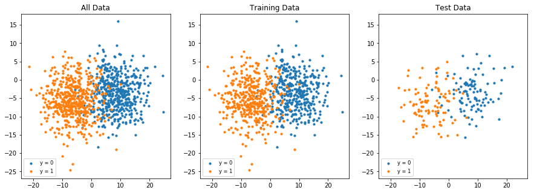

```python
f, (ax0, ax1, ax2) = plt.subplots(1, 3, figsize=(15,5))

ax0.scatter(X[y==0,0], X[y==0,1], s=10, label='y = 0')
ax0.scatter(X[y==1,0], X[y==1,1], s=10, label='y = 1')
ax0.set_title('All Data')
ax0.legend(loc='lower left', fontsize='small')
# Let's store the automatically determined axis limits of the first plot
xlim = ax0.get_xlim()
ylim = ax0.get_ylim()

ax1.scatter(X_train[y_train==0,0], X_train[y_train==0,1], s=10, label='y = 0')
ax1.scatter(X_train[y_train==1,0], X_train[y_train==1,1], s=10, label='y = 1')
ax1.set_title('Training Data')
ax1.legend(loc='lower left', fontsize='small')
# Use the axis limits from above here
ax1.set_xlim(xlim)
ax1.set_ylim(ylim)

ax2.scatter(X_test[y_test==0,0], X_test[y_test==0,1], s=10, label='y = 0')
ax2.scatter(X_test[y_test==1,0], X_test[y_test==1,1], s=10, label='y = 1')
ax2.set_title('Test Data')
ax2.legend(loc='lower left', fontsize='small')
# Use the axis limits from above here
ax2.set_xlim(xlim)
ax2.set_ylim(ylim);
```

## Use Scikit-Learn's Built-In Logistic Regression

Next we train a logisitc regression model using Scikit-Learn's [LogisticRegression](http://scikit-learn.org/stable/modules/generated/sklearn.linear_model.LogisticRegression.html) on the training data. It's just one line!

```python
predictor = LogisticRegression(random_state=SEED).fit(X_train, y_train)
```

How well does this model do on the training data and, more interestingly, on the test data? Let's find out by first using the trained model to predict the labels of the training and test data, and then computing several performance metrics:

- Accuracy (using scikit-learn's [accuracy_score](http://scikit-learn.org/stable/modules/generated/sklearn.metrics.accuracy_score.html))
- Precision (using scikit-learn's [precision_score](http://scikit-learn.org/stable/modules/generated/sklearn.metrics.precision_score.html))
- Recall (using scikit-learn's [recall_score](http://scikit-learn.org/stable/modules/generated/sklearn.metrics.recall_score.html))
- F1 (using scikit-learn's [f1_score](http://scikit-learn.org/stable/modules/generated/sklearn.metrics.f1_score.html))

```python
y_train_pred = predictor.predict(X_train)
y_test_pred = predictor.predict(X_test)
print('           Training Data   Test Data')
print('Accuracy   %.4f          %.4f' % (accuracy_score(y_train, y_train_pred), accuracy_score(y_test, y_test_pred)))
print('Precision  %.4f          %.4f' % (precision_score(y_train, y_train_pred), precision_score(y_test, y_test_pred)))
print('Recall     %.4f          %.4f' % (recall_score(y_train, y_train_pred), recall_score(y_test, y_test_pred)))
print('F1         %.4f          %.4f' % (f1_score(y_train, y_train_pred), f1_score(y_test, y_test_pred)))
```

```
           Training Data   Test Data
Accuracy   0.9300          0.9250
Precision  0.9343          0.9208
Recall     0.9250          0.9300
F1         0.9296          0.9254
```

Not too bad, 92.5% of the points in the test data were predicted correctly. We can extract the model's parameters and use them to draw the decision boundary:

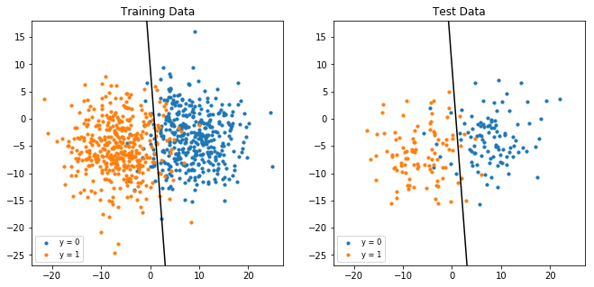

```python
w = predictor.coef_.T # transpose to make it a column vector, like in the lecture
b = predictor.intercept_
xx = np.arange(-5, 5, 0.1)
yy = - ( w[0,0] * xx + b ) / w[1,0]

f, (ax0, ax1) = plt.subplots(1, 2, figsize=(11,5))
ax0.scatter(X_train[y_train==0,0], X_train[y_train==0,1], s=10, label='y = 0')
ax0.scatter(X_train[y_train==1,0], X_train[y_train==1,1], s=10, label='y = 1')
# Let's store the automatically determined axis limits after the `scatter` step
xlim = ax0.get_xlim()
ylim = ax0.get_ylim()
ax0.plot(xx, yy, 'black')
# Restore the axis limits from above
ax0.set_xlim(xlim)
ax0.set_ylim(ylim)
ax0.legend(loc='lower left', fontsize='small')
ax0.set_title('Training Data')

ax1.scatter(X_test[y_test==0,0], X_test[y_test==0,1], s=10, label='y = 0')
ax1.scatter(X_test[y_test!=0,0], X_test[y_test!=0,1], s=10, label='y = 1')
# Let's store the automatically determined axis limits after the `scatter` step
xlim = ax0.get_xlim()
ylim = ax0.get_ylim()
ax1.plot(xx, yy, 'black')
# Restore the axis limits from above
ax1.set_xlim(xlim)
ax1.set_ylim(ylim)
ax1.legend(loc='lower left', fontsize='small')
ax1.set_title('Test Data');
```

## Exercise: Repeat the Above with More Interesting Data

With the two slightly overlapping point clouds above, we achieved an accuracy of 92.5% on the test data using logistic regression, a linear model. Repeat the above, but generate a more interesting dataset, using scikit-learn's [make_moons](http://scikit-learn.org/stable/modules/generated/sklearn.datasets.make_moons.html).

- Create data using `X, y = make_moons(n_samples=1000, noise=0.15, random_state=SEED)`
- Make a stratified 80%-20% train-test split
- Train a logistic regression classifier using the training data
- Predict the labels for the training and test data
- Compute accuracy, precision, recall and F1
- Visualize the decision boundary
- Use `random_state=SEED` where appropriate, for reproducible results
- Use the same variable names as above (`X`, `y`, `X_train`, `X_test`, `y_train`, `y_test`, `w`, `b`), i.e., overwrite these variables

```python
#Create data
X, y = make_moons(n_samples=1000, noise=0.15, random_state=SEED)

#Split 80% - 20%
X_train, X_test, y_train, y_test = train_test_split(X, y, test_size=0.2, random_state=SEED, stratify=y)
```

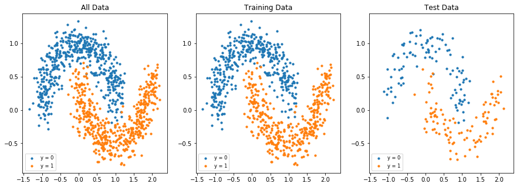

```python
#Plot data
f, (ax0, ax1, ax2) = plt.subplots(1, 3, figsize=(15,5))

ax0.scatter(X[y==0,0], X[y==0,1], s=10, label='y = 0')
ax0.scatter(X[y==1,0], X[y==1,1], s=10, label='y = 1')
ax0.set_title('All Data')
ax0.legend(loc='lower left', fontsize='small')
# Let's store the automatically determined axis limits of the first plot
xlim = ax0.get_xlim()
ylim = ax0.get_ylim()

ax1.scatter(X_train[y_train==0,0], X_train[y_train==0,1], s=10, label='y = 0')
ax1.scatter(X_train[y_train==1,0], X_train[y_train==1,1], s=10, label='y = 1')
ax1.set_title('Training Data')
ax1.legend(loc='lower left', fontsize='small')
# Use the axis limits from above here
ax1.set_xlim(xlim)
ax1.set_ylim(ylim)

ax2.scatter(X_test[y_test==0,0], X_test[y_test==0,1], s=10, label='y = 0')
ax2.scatter(X_test[y_test==1,0], X_test[y_test==1,1], s=10, label='y = 1')
ax2.set_title('Test Data')
ax2.legend(loc='lower left', fontsize='small')
# Use the axis limits from above here
ax2.set_xlim(xlim)
ax2.set_ylim(ylim);
```

Judging from the plots above a linear regression is doomed to fail.

```python
#Train predictor
predictor = LogisticRegression(random_state=SEED).fit(X_train, y_train)
```

```python
y_train_pred = predictor.predict(X_train)
y_test_pred = predictor.predict(X_test)
print('           Training Data   Test Data')
print('Accuracy   %.4f          %.4f' % (accuracy_score(y_train, y_train_pred), accuracy_score(y_test, y_test_pred)))
print('Precision  %.4f          %.4f' % (precision_score(y_train, y_train_pred), precision_score(y_test, y_test_pred)))
print('Recall     %.4f          %.4f' % (recall_score(y_train, y_train_pred), recall_score(y_test, y_test_pred)))
print('F1         %.4f          %.4f' % (f1_score(y_train, y_train_pred), f1_score(y_test, y_test_pred)))
```

```
           Training Data   Test Data
Accuracy   0.8962          0.8500
Precision  0.8972          0.8125
Recall     0.8950          0.9100
F1         0.8961          0.8585
```

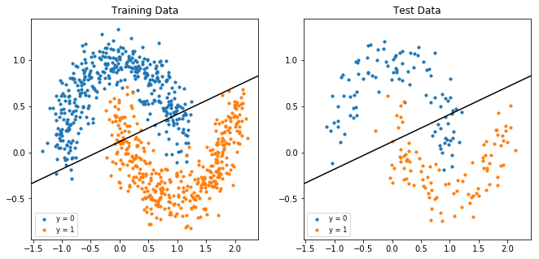

```python
w = predictor.coef_.T # transpose to make it a column vector, like in the lecture
b = predictor.intercept_
xx = np.arange(-5, 5, 0.1)
yy = - ( w[0,0] * xx + b ) / w[1,0]

f, (ax0, ax1) = plt.subplots(1, 2, figsize=(11,5))
ax0.scatter(X_train[y_train==0,0], X_train[y_train==0,1], s=10, label='y = 0')
ax0.scatter(X_train[y_train==1,0], X_train[y_train==1,1], s=10, label='y = 1')
# Let's store the automatically determined axis limits after the `scatter` step
xlim = ax0.get_xlim()
ylim = ax0.get_ylim()
ax0.plot(xx, yy, 'black')
# Restore the axis limits from above
ax0.set_xlim(xlim)
ax0.set_ylim(ylim)
ax0.legend(loc='lower left', fontsize='small')
ax0.set_title('Training Data')

ax1.scatter(X_test[y_test==0,0], X_test[y_test==0,1], s=10, label='y = 0')
ax1.scatter(X_test[y_test!=0,0], X_test[y_test!=0,1], s=10, label='y = 1')
# Let's store the automatically determined axis limits after the `scatter` step
xlim = ax0.get_xlim()
ylim = ax0.get_ylim()
ax1.plot(xx, yy, 'black')
# Restore the axis limits from above
ax1.set_xlim(xlim)
ax1.set_ylim(ylim)
ax1.legend(loc='lower left', fontsize='small')
ax1.set_title('Test Data');
```

As predicted the results are not very good.

## The Weakness of Accuracy

Before we move on to neural networks, let's look at an illustrative example where accuracy is an unsuitable measure of performance.

We are given a labeled data set (X, y) for binary classification and two prediction models and we want to see which model performs better.

```python
# Let's load the data and the two models from disk.
X_u = joblib.load(open('X.pkl', 'rb'))
y_u = joblib.load(open('y.pkl', 'rb'))
model_1 = joblib.load(open('model1.pkl', 'rb'))
model_2 = joblib.load(open('model2.pkl', 'rb'))

# We can use the models to predict the class labels y.
y_pred_model_1 = model_1.predict(X_u)
y_pred_model_2 = model_2.predict(X_u)

# Let's compare their accuracies with respect to the true labels y.
print('Model 1 accuracy: %f' % accuracy_score(y_u, y_pred_model_1))
print('Model 2 accuracy: %f' % accuracy_score(y_u, y_pred_model_2))
```

```
Model 1 accuracy: 0.954000
Model 2 accuracy: 0.979000
```

They both seem pretty good. Model 2, with almost 98 % correct predictions, seems to be the better one.

We learned in the first lecture that accuracy is problematic with strongly unbalanced data. So let's look at the class distributions.

```python
print('Total: %4d   Class 0: %4d   Class 1: %4d' % (len(y_u), (y_u==0).sum(), (y_u==1).sum()))
```

```
Total: 1000   Class 0:  980   Class 1:   20
```

Only 20 of 1000 examples in this data belong to Class 1, the data is indeed unbalanced. But is this a problem and if yes why? Let's plot the data with the true labels, the labels from Model 1 and the labels from Model 2.

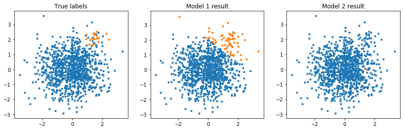

```python
f, (ax0, ax1, ax2) = plt.subplots(1, 3, figsize=(14, 4))

ax0.scatter(X_u[y_u==0][:,0], X_u[y_u==0][:,1], s=10)
ax0.scatter(X_u[y_u==1][:,0], X_u[y_u==1][:,1], s=10)
ax0.set_title('True labels')

ax1.scatter(X_u[y_pred_model_1==0][:,0], X_u[y_pred_model_1==0][:,1], s=10)
ax1.scatter(X_u[y_pred_model_1==1][:,0], X_u[y_pred_model_1==1][:,1], s=10)
ax1.set_title('Model 1 result')

ax2.scatter(X_u[y_pred_model_2==0][:,0], X_u[y_pred_model_2==0][:,1], s=10)
ax2.scatter(X_u[y_pred_model_2==1][:,0], X_u[y_pred_model_2==1][:,1], s=10)
ax2.set_title('Model 2 result');
```

In reality (left), the few points belonging to Class 1 are in a small, more or less circular region to the upper right of the rest of the data.

Model 1 (middle) seems to be a linear model, which cuts the space into two parts using a straight line, where the upper right corner belongs to Class 1. Not great, but it gets the job somewhat done.

But what about Model 2 (right)? It only predicted a single point to belong to Class 1! All other 999 points are predicted to belong to Class 0.

For our intuition, the result from Model 1 seems to be better than that from Model 2. In fact, Model 2 is a completely uninformed model that always returns Class 0 for all points you give it, except a single one, which is picked at random (you can look at the file `dummy_predictor.py`).

Accuracy means measuring the percentage of correctly predicted points. With strongly unbalanced classes, like we have them here with 98 % of the points belonging to Class 0 (according to the true labels), uninformed models that simply favor the majority classs (such as our Model 2) will achieve high accuracy, because they are right most of the time. But clearly a model like Model 2 is not useful in practice.

What kind of results do the other measures we talked about, precision, recall and F1, give for this situation?

```python
acc_m1 = accuracy_score(y_u, y_pred_model_1)
prec_m1 = precision_score(y_u, y_pred_model_1)
recall_m1 = recall_score(y_u, y_pred_model_1)
f1_m1 = f1_score(y_u, y_pred_model_1)

acc_m2 = accuracy_score(y_u, y_pred_model_2)
prec_m2 = precision_score(y_u, y_pred_model_2)
recall_m2 = recall_score(y_u, y_pred_model_2)
f1_m2 = f1_score(y_u, y_pred_model_2)

print('%-10s %-10s %-10s' % ('Measure', 'Model 1', 'Model 2'))
print('-' * 30)
print('%-10s %.6f   %.6f' % ('Accuracy', acc_m1, acc_m2))
print('%-10s %.6f   %.6f' % ('Precision', prec_m1, prec_m2))
print('%-10s %.6f   %.6f' % ('Recall', recall_m1, recall_m2))
print('%-10s %.6f   %.6f' % ('F1', f1_m1, f1_m2))
```

```
Measure    Model 1    Model 2
------------------------------
Accuracy   0.954000   0.979000
Precision  0.303030   0.000000
Recall     1.000000   0.000000
F1         0.465116   0.000000
```

Model 2 has higher accuracy, but both precision and recall (and therefore also F1) are zero, because there was not a single true positive.

Model 1 on the other hand achieves a recall of 1.0, because all of the 20 points that actually belong to Class 1 were labeled as Class 1. Precision is only about 0.3 because this model also labeled many additional points as Class 1 that really belonged to Class 0 (false positives). The harmonic mean of 1.0 and 0.3, the F1 score, is about 0.47.

Looking at precision, recall and F1 instead of accuracy gave a much more representative picture in this situation with strongly unbalanced classes in the data.

## Exercise: Forward Pass of a Minimal Neural Network (Logistic Regression)

In class, we have discussed that logistic regression can be understood as a single-layer (actually even single-unit) neural network. For 2-dimensional input $\large \boldsymbol{x} \in \mathbb{R}^2$, we had:

$$\Large z = w_1 x_1 + w_2 x_2 + b\\ \Large \hat{y} = \sigma(z)$$

where $\Large \sigma(z)$ is the logistic function:

$$\Large \sigma(z) = \frac{1}{1 + e^{-z}}$$

This is illustrated by the following computational graph from the lecture slides:

[figure not shown]

The logistic function can be implemented using [np.exp](https://docs.scipy.org/doc/numpy-1.14.0/reference/generated/numpy.exp.html) as follows. It will work for scalar inputs as well as for vectors, because `np.exp` computes the exponential function *element-wise*, and because NumPy automatically uses [broadcasting](https://docs.scipy.org/doc/numpy-1.14.0/user/basics.broadcasting.html) when we ask for something like `np.array([1,2,3,4]) + 42`.

```python
def sigmoid(z):
    return 1 / (1 + np.exp(-z))
```

### 2D version

To get there step by step, first implement a 2D version of a logistic regression neural network, i.e., one that is fixed to two-dimensional input.

```python
def my_log_reg_2d(x1, x2, w1, w2, b):

    ### YOUR CODE HERE ###
    z = x1*w1 + x2*w2 + b
    yhat = sigmoid(z)
    ### END OF YOUR CODE ###

    return yhat
```

Let us re-use the data we generated with `make_moons` above and the weights and bias from the logistic regression model we trained using scikit-learn (if this fails, you might need to re-run the code cells above, and make sure that you didn't overwrite the variables used below).

```python
print('X_test.shape = ', X_test.shape)
print('y_test.shape = ', y_test.shape)
m_test = X_test.shape[0]
print('m_test = ', m_test)
print('w = ', w)
print('b = ', b)
```

```
X_test.shape =  (200, 2)
y_test.shape =  (200,)
m_test =  200
w =  [[ 1.44677221]
 [-4.87745363]]
b =  [0.55532666]
```

Next, loop over the test data and apply your function `my_log_reg_2d` to each point:

```python
# initialize result vector to zeros
y_test_prob_mine_2d = np.zeros(m_test)

# loop over test data
for i in range(m_test):
    y_test_prob_mine_2d[i] = my_log_reg_2d(X_test[i,0], X_test[i,1], w[0,0], w[1,0], b)

print(y_test_prob_mine_2d)
```

```
[0.73985388 0.93317065 0.13595577 0.40450856 0.35230835 0.70910313
 0.03550598 0.00633388 0.9395966  0.0290484  0.54014149 0.62723871
 0.75894407 0.82587283 0.97184083 0.97464286 0.75654523 0.00342595
 0.86246198 0.04902896 0.9855125  0.9839644  0.07767079 0.07376988
 0.97883008 0.07275579 0.80049436 0.72929261 0.01922998 0.78313575
 0.00831644 0.82645608 0.21417302 0.91972673 0.84457745 0.99284306
 0.95376831 0.01369984 0.00525331 0.03762141 0.98925368 0.00915953
 0.90716628 0.8979228  0.02180149 0.87855136 0.98014908 0.10743528
 0.99395339 0.93355166 0.01768194 0.90868317 0.90412059 0.89824895
 0.04765286 0.02503935 0.00912354 0.06022366 0.55386242 0.02560994
 0.26797213 0.8005297  0.73094782 0.99293155 0.84336328 0.21920535
 0.94849278 0.75615266 0.032956   0.98593926 0.97321456 0.06080932
 0.01416548 0.00411284 0.16651799 0.9943724  0.65113418 0.01077059
 0.99256529 0.27289137 0.92031513 0.94007527 0.73885188 0.94347094
 0.77229513 0.34529357 0.90828805 0.78469966 0.01611178 0.95843558
 0.50716095 0.25085126 0.49754697 0.24698067 0.79938674 0.97542805
 0.03548984 0.91032618 0.4722636  0.81806259 0.95823397 0.798219
 0.99591083 0.01225639 0.10328884 0.02535    0.88360768 0.98171431
 0.86319572 0.0316126  0.09442112 0.72370109 0.01423743 0.97592077
 0.99214286 0.13904668 0.07983268 0.88000161 0.90845971 0.88324488
 0.31565748 0.00626105 0.02594253 0.05008234 0.98309544 0.96377467
 0.99233137 0.29124817 0.22251345 0.09160827 0.05136268 0.01299505
 0.60516199 0.99343881 0.9353706  0.49748421 0.9407549  0.98228302
 0.97171252 0.32193836 0.94918893 0.97421096 0.07811568 0.77635378
 0.90191911 0.0123721  0.04087648 0.01199016 0.99556015 0.83144431
 0.87914041 0.01699632 0.96327999 0.80809021 0.03088516 0.95729998
 0.66790481 0.15479697 0.03033469 0.90728195 0.79445502 0.907695
 0.9892251  0.00594224 0.7356295  0.99077956 0.0214693  0.00562318
 0.97314632 0.07070619 0.0116189  0.08069769 0.99298154 0.95708628
 0.94193983 0.0104169  0.00603095 0.62075367 0.14376383 0.16420648
 0.01602569 0.4610951  0.00341689 0.22232499 0.97779969 0.02016633
 0.78962561 0.9597951  0.01101635 0.02856351 0.99457151 0.97105325
 0.99002602 0.93753506 0.99754478 0.97929568 0.01922155 0.01302763
 0.62143197 0.99062833]
```

Our network's output is a probability (between 0 and 1) for each of the test points, indicating how sure the model is about the data point belonging to the first class (value close to 0) or the second class (value close to 1). Let's apply a threshold to get predicted class labels instead of probabilities:

```python
y_test_pred_mine_2d = (y_test_prob_mine_2d > 0.5) * 1
print(y_test_pred_mine_2d)
```

```
[1 1 0 0 0 1 0 0 1 0 1 1 1 1 1 1 1 0 1 0 1 1 0 0 1 0 1 1 0 1 0 1 0 1 1 1 1
 0 0 0 1 0 1 1 0 1 1 0 1 1 0 1 1 1 0 0 0 0 1 0 0 1 1 1 1 0 1 1 0 1 1 0 0 0
 0 1 1 0 1 0 1 1 1 1 1 0 1 1 0 1 1 0 0 0 1 1 0 1 0 1 1 1 1 0 0 0 1 1 1 0 0
 1 0 1 1 0 0 1 1 1 0 0 0 0 1 1 1 0 0 0 0 0 1 1 1 0 1 1 1 0 1 1 0 1 1 0 0 0
 1 1 1 0 1 1 0 1 1 0 0 1 1 1 1 0 1 1 0 0 1 0 0 0 1 1 1 0 0 1 0 0 0 0 0 0 1
 0 1 1 0 0 1 1 1 1 1 1 0 0 1 1]
```

Finally, we can compare if our model produced the same end result as scikit-learn's `predict`:

```python
# This should return 'True'
np.allclose(y_test_pred, y_test_pred_mine_2d)
```

```
True
```

### Loop Version

A more flexible version would allow arbitrary input dimensionality, not just 2D. Also, it would be more convenient if the forward-pass function would take care of looping over the data we give it. Complete the following function:

```python
def my_log_reg_loop(X, w, b):
    # X ... a matrix containing data points of shape (numer of data points) x (number of dimensions)
    # w ... the weight vector, of shape (number of dimensions) x 1
    # b ... the bias, a scalar

    # initialize result vector to zeros
    result = np.zeros(X.shape[0])

    # loop over the data points
    for i in range(X.shape[0]):
        # loop over the dimensions
        for j in range(X.shape[1]):
            # add the weighted input to the result
            result[i] += X[i][j] * w[j];

        # add the bias
        result[i] += b;

        # apply the activation function
        result[i] = sigmoid(result[i])
    return result
```

Again, let's apply a threshold and compare to the result from earlier:

```python
y_test_prob_mine_loop = my_log_reg_loop(X_test, w, b)
y_test_pred_mine_loop = (y_test_prob_mine_loop > 0.5) * 1
# This should return 'True'
np.allclose(y_test_pred, y_test_pred_mine_loop)
```

```
True
```

### Vectorized Version

Finally, all this looping is really not necessary. We can achieve the same result using a vector dot product, using NumPy's [np.dot](https://docs.scipy.org/doc/numpy-1.14.0/reference/generated/numpy.dot.html):

```python
def my_log_reg_vec(X, w, b):
    result = sigmoid(np.dot(X, w) + b)
    return result.reshape(-1,)
```

The variable `result` above holds a column vector of shape `(200, 1)`, in line with our notation from the lecture. However, the prediction result from scikit-learn, which we have in the variable `y_test_pred`, is of shape `(200,)`. This is called a rank-1 array, and it's neither a column vector nor a row vector. Because we want to compare the two, to see whether our implementation is correct (below), we needed to `reshape` the column vector above to the same shape as scikit-learn's result.

```python
y_test_prob_mine_vec = my_log_reg_vec(X_test, w, b)
y_test_pred_mine_vec = (y_test_prob_mine_vec > 0.5) * 1
# This should return 'True'
np.allclose(y_test_pred, y_test_pred_mine_vec)
```

```
True
```

## Exercise: Implement the forward pass for a bigger neural network

Finally, let us implement the forward pass for a bigger neural network. Using the notation from class, we were able to elegantly specify the activations at each layer using recursion, starting from the input layer ($\large \ell = 0$) and finishing at the output layer ($\large \ell = L$):

[figure not shown]

$$\large \begin{array}{rl} A^{[0]} & = X\\ z^{[1]} & = A^{[0]} W^{[1]} + b^{[1]}\\ A^{[1]} & = r(z^{[1]})\\ \\ z^{[\ell]} & = A^{[\ell-1]} W^{[\ell]} + b^{[\ell]}\\ A^{[\ell]} & = g^{[\ell]}(z^{[\ell]})\\ \\ \hat{Y} & = A^{[L]} \end{array} $$

We should be able to use the same principle in code.

Let's assume a network for binary classification like the one depicted above, where all layers use the rectified linear function (ReLU) as activation function, except the last layer, which uses a sigmoid function. Furthermore, let's assume we are simply given the weights and biases for each layer (for now we don't worry where they come from). Let's go ahead and implement the forward pass!

We have already defined the sigmoid function above. The ReLU function can be implemented using NumPy in the following way. Note that `>` here is overloaded and refers to [numpy.greater](https://docs.scipy.org/doc/numpy-1.14.0/reference/generated/numpy.greater.html) and that for the comparison `z > 0` [NumPy broadcasting](https://docs.scipy.org/doc/numpy-1.14.0/user/basics.broadcasting.html) is applied. Thus, this `relu` function can be applied to scalars, vectors, matrices, etc.; and it will apply the funtion element-wise.

```python
def relu(z):
    return z * (z > 0)
```

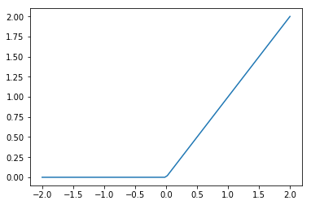

```python
xs = np.linspace(-2, 2, 100)
ys = relu(xs)
plt.plot(xs, ys);
```

Let's load ready-to-use weights and biases from a file. `weights` and `biases` will both be Python dictionaries, where the keys are integers indicating the layer, and the values are NumPy matrices. Then we build a Python list of function "pointers", such that index `0` corresponds to the input layer (no activation function), all but the last entries are the above defined `relu` function, and the last entry is the `sigmoid` function.

```python
weights, biases = joblib.load('MLP_parameters.pkl')
activation_functions = [ None ] + [ relu ] * (len(weights)-1) + [ sigmoid ]
```

Go ahead and inspect these variables, to get a good understanding of what you are starting from:

```python
print(activation_functions)
print(biases[1].shape)
print(weights[1].shape)
print(weights[2].shape)
print(len(weights))

print(weights[1])
biases
```

```
[None, <function relu at 0x000002561E01F9D8>, <function sigmoid at 0x000002561DB20B70>]
(1, 32)
(2, 32)
(32, 1)
2
[[ 0.967736    0.72113174  0.07085465 -1.4451671  -0.5810676  -2.2092264
  -0.31344375 -1.2188897  -1.996478    0.1778437  -0.18313053 -0.4133466
   0.73118144  1.2586086  -0.04903942 -0.9440649  -0.19815952 -0.37783977
   0.48318857 -2.1287374  -0.7082971   0.05100678 -1.6945242   1.0692039
   1.0684003   0.25754297 -1.5757357   0.9646296   2.3290577   1.8298385
   0.16262954 -2.1084762 ]
 [ 1.0649047   0.9296617  -0.2489122  -0.01350856  0.41567412 -0.14926843
  -0.6300168  -0.97763216  0.98256373 -0.41823822  2.1082551   2.1853132
   0.98421633  1.5231209  -0.26038978  0.20846412 -0.28251496  1.0429043
  -1.2893794  -1.0250927   1.3779083  -0.4239829   0.06967951 -0.26253435
   0.6890802  -1.4130385  -1.2671216  -0.3283128  -0.02365706 -0.01999427
  -0.2627298  -0.3991223 ]]
```

```
{1: array([[-1.2560698 , -0.20885272,  1.2873398 ,  0.00537439, -1.8339775 ,
          0.06614189, -0.9118517 ,  1.3164233 , -0.4328656 , -0.82471436,
          1.3731439 , -1.3082063 , -0.9811211 , -0.52086514, -0.8002177 ,
         -1.4401612 , -0.4515153 , -1.0247874 ,  1.20906   ,  0.30981317,
          0.2354559 , -0.03706814, -0.01892071, -2.4782784 , -0.20299977,
          0.5550074 ,  0.4376994 ,  0.10502114, -2.3207967 , -1.8233042 ,
         -1.4004402 ,  2.0474086 ]], dtype=float32),
 2: array([1.0202034], dtype=float32)}
```

Note that you can use the functions in the list `activation_functions` like this:

```python
# apply the function at index 2 to the input value 0
a = activation_functions[2](0)
b = sigmoid(0)
print('a is %f\nb is %f' % (a, b))
```

```
a is 0.500000
b is 0.500000
```

```python
def testIt(X, weights, biases, activation_functions):
    activations = { 0: X }
    wusa = np.dot(activations[0], weights[1])
    activations[1] = activation_functions[1](wusa + biases[1])
    return activations

#testIt(X_train, weights, biases, activation_functions)
X_train.shape[0]
```

```
800
```

```python
def forward_pass(X, weights, biases, activation_functions):
    # This dictionary will hold the activations of each layer:
    activations = { 0: X }

    ### YOUR CODE HERE ###
    # Now loop over the layers and compute the activations, using the
    # activations of the previous layer, the current weights, biases
    # and activation function; as specified by the formulas above.
    # Use np.dot() for matrix multiplication.
    for l in range(1, len(weights) + 1):
        activations[l] = activation_functions[l](np.dot(activations[l - 1], weights[l]) + biases[l])

    # Finally, return the activations of the last layer (remove the
    # dummy code below).
    return activations[len(weights)]
```

Above, we evaluated logistic regression on a `make_moons`-generated dataset. Let's use the same data to compare that to the performance of the neural network we just implemented the forward pass for.

```python
y_train_prob_NN = forward_pass(X_train, weights, biases, activation_functions)
y_test_prob_NN = forward_pass(X_test, weights, biases, activation_functions)
y_train_pred_NN = (y_train_prob_NN > 0.5) * 1
y_test_pred_NN = (y_test_prob_NN > 0.5) * 1
print('           Training Data   Test Data')
print('Accuracy   %.4f          %.4f' % (accuracy_score(y_train, y_train_pred_NN), accuracy_score(y_test, y_test_pred_NN)))
print('Precision  %.4f          %.4f' % (precision_score(y_train, y_train_pred_NN), precision_score(y_test, y_test_pred_NN)))
print('Recall     %.4f          %.4f' % (recall_score(y_train, y_train_pred_NN), recall_score(y_test, y_test_pred_NN)))
print('F1         %.4f          %.4f' % (f1_score(y_train, y_train_pred_NN), f1_score(y_test, y_test_pred_NN)))
```

```
           Training Data   Test Data
Accuracy   0.9900          0.9850
Precision  0.9900          0.9709
Recall     0.9900          1.0000
F1         0.9900          0.9852
```

Use the following code to draw the decision boundary represented by the neural network:

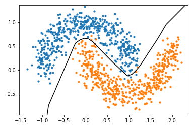

```python
xx, yy = np.mgrid[xlim[0]:xlim[1]:.1, ylim[0]:ylim[1]:.1]
grid = np.c_[xx.ravel(), yy.ravel()]
probs = forward_pass(grid, weights, biases, activation_functions)
f, ax = plt.subplots(1, 1)
ax.scatter(X[y==0,0], X[y==0,1], s=10, label='y = 0')
ax.scatter(X[y!=0,0], X[y!=0,1], s=10, label='y = 1')
ax.contour(xx, yy, probs.reshape(xx.shape), 1, colors='black');
```